# Data Science and Predictive Analytics (UMich HS650)

## 5.3 GLMM

```r
# scale some features
dataPD_new$L_cingulate_gyrus_ComputeArea <- scale(dataPD_new$L_cingulate_gyrus_ComputeArea)
dataPD_new$L_cingulate_gyrus_Volume <- scale(dataPD_new$L_cingulate_gyrus_Volume)
dataPD_new$R_cingulate_gyrus_ComputeArea <- scale(dataPD_new$R_cingulate_gyrus_ComputeArea)
dataPD_new$R_cingulate_gyrus_Volume<-scale(dataPD_new$R_cingulate_gyrus_Volume)
dataPD_new$R_insular_cortex_ComputeArea<-scale(dataPD_new$R_insular_cortex_ComputeArea)
dataPD_new$R_insular_cortex_Volume<-scale(dataPD_new$R_insular_cortex_Volume)

# define the outcome UPDRS and imaging latent feature
dataPD_new$UPDRS<-dataPD_new$UPDRS_part_I+1.890*dataPD_new$UPDRS_part_II+2.345*dataPD_new$UPDRS_part_III
dataPD_new$Imaging<-dataPD_new$L_cingulate_gyrus_ComputeArea  +0.994*dataPD_new$L_cingulate_gyrus_Volume+0.961*dataPD_new$R_cingulate_gyrus_ComputeArea+0.955*dataPD_new$R_cingulate_gyrus_Volume+0.930*dataPD_new$R_insular_cortex_ComputeArea+0.920*dataPD_new$R_insular_cortex_Volume

model.glmm<-glmer(ResearchGroup~UPDRS+Imaging+Age+Sex+Weight+(1|FID_IID), data=dataPD_new, family="binomial")
arm::display(model.glmm)
```

```
## glmer(formula = ResearchGroup ~ UPDRS + Imaging + Age + Sex +
##     Weight + (1 | FID_IID), data = dataPD_new, family = "binomial")
##             coef.est coef.se
## (Intercept) -58.42     0.00
## UPDRS        -3.37     0.00
## Imaging       1.89     0.00
## Age           0.88     0.00
## Sex2          1.37     0.00
## Weight        0.66     0.00
##
## Error terms:
##  Groups   Name        Std.Dev.
##  FID_IID  (Intercept) 50.44
##  Residual              1.00
## ---
## number of obs: 1206, groups: FID_IID, 440
## AIC = 96.8, DIC = -81.9
## deviance = 0.4
```

```r
dataPD_new$predictedGLMM <- predict(model.glmm, newdata=dataPD_new[1:1764, !(names(dataPD_new) %in% c("ResearchGroup", "UPDRS_part_II_T4"))], allow.new.levels=T, type="response")  # lme4::predict.merMod()
# factorize the predictions
dataPD_new$predictedGLMM <- factor(ifelse(dataPD_new$predictedGLMM<0.5, "0", "1"))

# compare overall the GLMM-predicted values against observed ResearchGroup labels values
# install.packages("caret")
# library("caret")
caret::confusionMatrix(dataPD_new$predictedGLMM, dataPD_new$ResearchGroup)
```

```
## Confusion Matrix and Statistics
##
##           Reference
## Prediction    0    1
##          0 1079    0
##          1    0  127
##
##                Accuracy : 1
##                  95% CI : (0.9969, 1)
##     No Information Rate : 0.8947
##     P-Value [Acc > NIR] : < 2.2e-16
##
##                   Kappa : 1
##  Mcnemar's Test P-Value : NA
##
##             Sensitivity : 1.0000
##             Specificity : 1.0000
##          Pos Pred Value : 1.0000
##          Neg Pred Value : 1.0000
##              Prevalence : 0.8947
##          Detection Rate : 0.8947
##    Detection Prevalence : 0.8947
##       Balanced Accuracy : 1.0000
##
##        'Positive' Class : 0
##
```

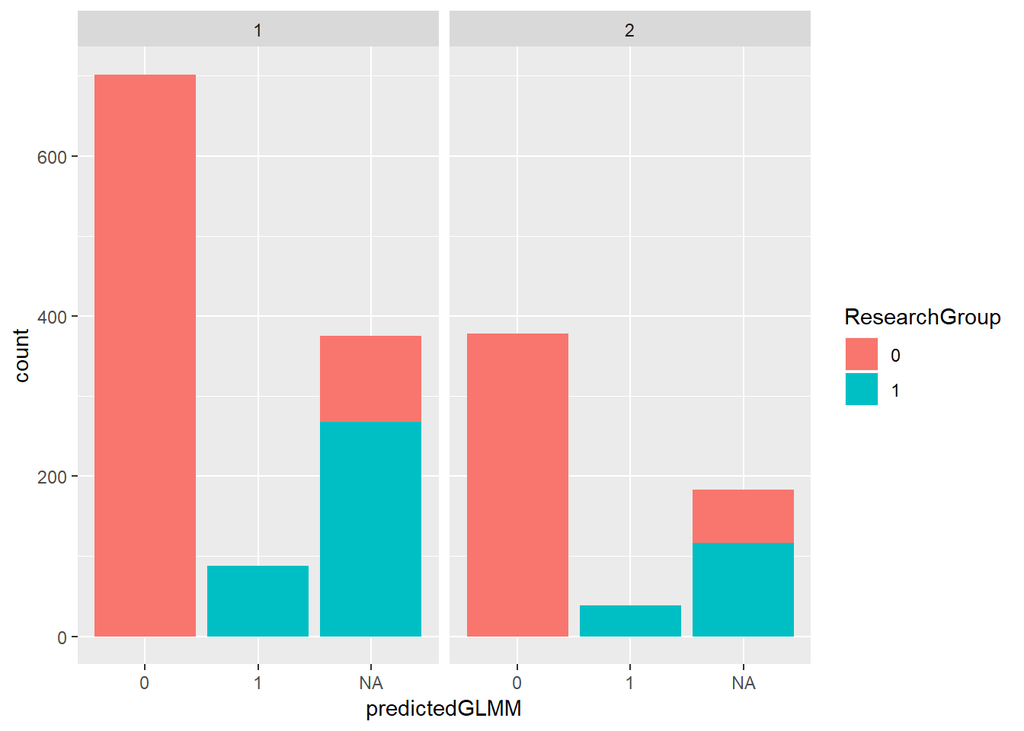

```r
# compare predited and observed by Sex
ggplot(dataPD_new, aes(predictedGLMM, fill=ResearchGroup)) +
   geom_bar() + facet_grid(. ~ Sex)
```

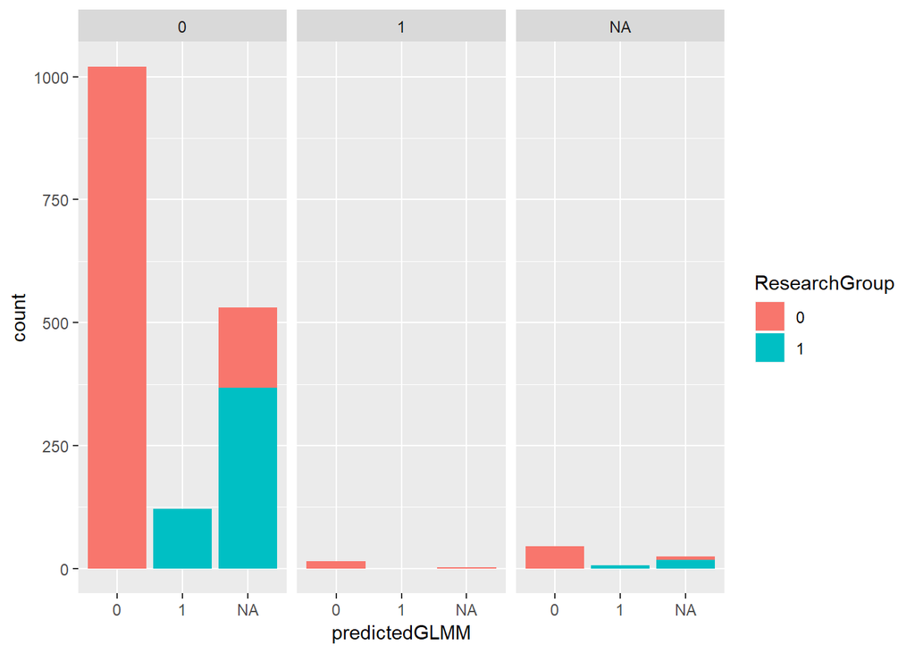

```r
# compare predited and observed by Genotype (chr12_rs34637584_GT)
ggplot(dataPD_new, aes(predictedGLMM, fill=ResearchGroup)) +
   geom_bar() + facet_grid(. ~ chr12_rs34637584_GT)
```

## 5.4 GEE

We can use several alternative R packages to fit and interpret GEE models, e.g., `gee` and `geepack`. Below we will demonstrate GEE modeling of the PD data using `gee`.

```r
# install.packages("geepack")
# library("geepack")
#gee.fit <- geeglm(ResearchGroup~Imaging+Age+Sex+Weight+UPDRS_part_I, data=dataPD_new[complete.cases(dataPD_new), ], family = "binomial", id = FID_IID, corstr = "exchangeable", scale.fix = TRUE)

library(gee)
# Full GEE model
gee.fit <- gee(ResearchGroup~Imaging+Age+Sex+Weight+UPDRS_part_I, data=dataPD_new, family = "binomial", id = FID_IID, corstr = "exchangeable", scale.fix = TRUE)
```

```
##   (Intercept)       Imaging           Age          Sex2        Weight
## -0.9612274596 -0.0463517707 -0.0099415181 -0.0605950335 -0.0009592125
##  UPDRS_part_I
## -0.5866705844
```

```r
# reduced model (-UPDRS_part_I)
gee.fit2 <- gee(ResearchGroup~Imaging+Age+Sex+Weight, data=dataPD_new, family = "binomial", id = FID_IID, corstr = "exchangeable", scale.fix = TRUE)
```

```
##  (Intercept)      Imaging          Age         Sex2       Weight
##  0.106938489 -0.039306507 -0.010051002 -0.295100962 -0.003659216
```

```r
summary(gee.fit)
```

```
##
##  GEE:  GENERALIZED LINEAR MODELS FOR DEPENDENT DATA
##  gee S-function, version 4.13 modified 98/01/27 (1998)
##
## Model:
##  Link:                      Logit
##  Variance to Mean Relation: Binomial
##  Correlation Structure:     Exchangeable
##
## Call:
## gee(formula = ResearchGroup ~ Imaging + Age + Sex + Weight +
##     UPDRS_part_I, id = FID_IID, data = dataPD_new, family = "binomial",
##     corstr = "exchangeable", scale.fix = TRUE)
##
## Summary of Residuals:
##        Min         1Q     Median         3Q        Max
## -0.3735213 -0.1958739 -0.1370021 -0.0701463  0.9662803
##
##
## Coefficients:
##                  Estimate  Naive S.E.    Naive z Robust S.E.   Robust z
## (Intercept)  -0.493190613 0.919383685 -0.5364361 1.012978539 -0.4868717
## Imaging      -0.043221623 0.017254202 -2.5049912 0.018888781 -2.2882166
## Age          -0.010064377 0.009939440 -1.0125698 0.011859148 -0.8486593
## Sex2         -0.111662440 0.252935779 -0.4414656 0.271071683 -0.4119296
## Weight       -0.001522845 0.006949881 -0.2191181 0.007416382 -0.2053353
## UPDRS_part_I -0.458581284 0.086798874 -5.2832631 0.072854390 -6.2944907
##
## Estimated Scale Parameter:  1
## Number of Iterations:  13
##
## Working Correlation
##           [,1]      [,2]      [,3]      [,4]
## [1,] 1.0000000 0.2538755 0.2538755 0.2538755
## [2,] 0.2538755 1.0000000 0.2538755 0.2538755
## [3,] 0.2538755 0.2538755 1.0000000 0.2538755
## [4,] 0.2538755 0.2538755 0.2538755 1.0000000
```

```r
# anova(gee.fit, gee.fit2) # compare two GEE models
# To test whether a categorical predictor with more than two levels should be retained in a GEE model we need to test the entire set of dummy variables simultaneously as a single construct.
# The geepack package provides a method for the anova function for a multivariate Wald test
# When the anova function is applied to a single geeglm object it returns sequential Wald tests for individual predictors with the tests carried out in the order the predictors are listed in the model formula.

# Individual Wald test and confidence intervals for each covariate
predictors <- coef(summary(gee.fit))
gee.fit.CI <- with(as.data.frame(predictors), cbind(lwr=Estimate-1.96*predictors[, 4], est=Estimate, upr=Estimate+1.96*predictors[, 4])) # predictors[, 4] == "Robust S.E."
rownames(gee.fit.CI) <- rownames(predictors)
gee.fit.CI
```

```
##                      lwr          est          upr
## (Intercept)  -2.47862855 -0.493190613  1.492247323
## Imaging      -0.08024363 -0.043221623 -0.006199612
## Age          -0.03330831 -0.010064377  0.013179554
## Sex2         -0.64296294 -0.111662440  0.419638058
## Weight       -0.01605895 -0.001522845  0.013013264
## UPDRS_part_I -0.60137589 -0.458581284 -0.315786678
```

```r
# exponentiate the interpret the results as "odds", instead of log-odds
UPSRS_est <- coef(gee.fit)["UPDRS_part_I"]
UPDRS_se <- summary(gee.fit)$coefficients["UPDRS_part_I", "Robust S.E."]

exp(UPSRS_est + c(-1, 1) * UPDRS_se * qnorm(0.975))
```

```
## [1] 0.5480585 0.7292131
```

The three models are not directly comparable because they are so intrinsically different. The table below reports the AIC, but we can also compute other model-quality metrics, for SEM, GLMM, and GEE.

```r
AIC(fitSEM1)
AIC(model.glmm)
# install.packages("MuMIn")
library("MuMIn")
# to rank several models based on QIC:
# model.sel(gee.fit, gee.fit2, rank = QIC)
QIC(gee.fit)
```

| . | SEM | GLMM | GEE |
| --- | --- | --- | --- |
| AIC | 4871 | 96.8 | 773.9 |

Try to apply some of these longitudinal data analytics on:

- The fMRI data we discussed in [Chapter 3 (Visualization)](http://www.socr.umich.edu/people/dinov/courses/DSPA_notes/03_DataVisualization.html#63_3d_and_4d_visualizations), and
- The [Diet-Exer-Pulse Data](https://umich.instructure.com/files/6009692/download?download_frd=1) fitting models for *Time* as a linear predictor of *Pulse*, accounting for the study design (diet by exercise).

# 6 Recurrent (RNN) and Long Short-Term Memory (LSTM) Networks

This Chapter is purposely divided in two separate sections to reduce the page loading time, stratify the extensive computational tasks, and improve the user experiences. The separate [RNN/LSTM section is available here](http://www.socr.umich.edu/people/dinov/courses/DSPA_notes/18_BigLongitudinalDataAnalysis_RNN.html), and it includes:

- Recurrent Neural Networks (RNN)
- Tensor Format Representation
- Simulated RNN case-study
- Climate Data Study
- Keras-based Multi-covariate LSTM Time-series Analysis and Forecasting.